# Movies Recommendation in Flixster

Robson Teixeira, Nuno Gomes

Sys.Date()

#### **Introduction**

This practical assignment aims to compare the performance of diferent recommendation strategies on a data set obtained from `Flixster`, a social movie site allowing users to share movie ratings, discover new movies and meet others with similar movie taste.

#### **Problem Definition**

Obtain recommendations of movies for a set of users.

#### **Data Preparation**

The `Flixster` dataset contains informations regarding the users like user id, gender, age, location, for how long it has been a member, contains information regarding movies as name and movie id and contains information on the ratings given by users to movies and on which date. This datas are distributed in following files:

- profile.txt
- movie-names.txt
- Ratings.time.txt

##### **Users Information**

Load user informations from profile.txt file:

```r
library(tidyverse)

#load user informations from profile.txt file and setting the NA strings
df_user <- read.csv("data/profile.txt", na.strings = c("N/A",""), stringsAsFactors = FALSE)

str(df_user)
```

```
## 'data.frame':    1002796 obs. of  7 variables:
##  $ userid     : int  981904 882359 921220 798641 952904 888 300293 805965 162134 611822 ...
##  $ gender     : chr  "Male" "Female" "Female" "Male" ...
##  $ location   : int  111 870 993 250 172 157 221 180 233 221 ...
##  $ memberfor  : chr  "2009-09-01 00:00:00" "2009-10-02 00:00:00" "2009-09-01 00:00:00" "2009-11-01 00:00:00" ...
##  $ lastlogin  : int  1 181 124 40 44 39 91 1 26 23 ...
##  $ profileview: chr  "19" "108" NA "22" ...
##  $ age        : chr  "19" "108" NA "22" ...
```

The data set consists of 1002796 observations spread across 7 variables:

| Variables | Type | Description |
| --- | --- | --- |
| userid | integer | User unique identifier |
| gender | character | User gender |
| location | integer | User location identifier |
| memberfor | Date | Date that user became member |
| lastlogin | integer | Identifier the last login |
| profileview | integer | Identifier the profile view |
| age | integer | User age |

The variables *location*, *memberfor*, *lastlogin* and *profileview* are not needed for the context this analysis, so they will be removed.

Getting the metrics about data set:

```r
#Remove no relevant variables
df_user <- select(df_user, -c(location, memberfor, lastlogin, profileview))

# Setting 'gender' as factors and 'age' as integer
df_user <- df_user %>% mutate(gender = as.factor(gender)) %>% mutate(age = as.integer(age))

summary(df_user)
```

```
##      userid           gender            age
##  Min.   :      1   Female:441074   Min.   : 12.00
##  1st Qu.: 250830   Male  :494193   1st Qu.: 21.00
##  Median : 548024   NA's  : 67529   Median : 25.00
##  Mean   : 536170                   Mean   : 27.39
##  3rd Qu.: 798766                   3rd Qu.: 31.00
##  Max.   :1049511                   Max.   :113.00
##                                    NA's   :255618
```

There are a significant number of *NA’s* in variables *gender* (67529 or around 6.73% of total) and *age* (255618 or around 25.49% of total). This data will be maintained.

Besides the NA’s, the variable *age* present inconsistent values. The maximum value assigned for this variable is 113 and there are around 2600 users with age over 90 years old.

```r
df_user %>% filter(age > 90) %>% count()
```

```
## # A tibble: 1 x 1
##       n
##   <int>
## 1  2608
```

##### **Movies Information**

Load movies information from movie-name.txt file:

```r
#load movies information from movie-name.txt file and setting the NA strings
df_movies <- read.delim("data/movie-names.txt", na.strings = c("N/A",""), stringsAsFactors = FALSE )

str(df_movies)
```

```
## 'data.frame':    66730 obs. of  2 variables:
##  $ moviename: chr  "$ (Dollars) (The Heist)" "$5 a Day (Five Dollars a Day)" "$9.99" "$windle (Swindle)" ...
##  $ movieid  : int  252 253 1 254 255 256 257 2 258 3 ...
```

The data set consists of 66730 observations spread across 2 variables:

| Variable | Type | Description |
| --- | --- | --- |
| moviename | character | Movie name |
| movieid | integer | Movie unique identifier |

Getting the metrics about data set:

```r
summary(df_movies)
```

```
##   moviename            movieid
##  Length:66730       Min.   :    1
##  Class :character   1st Qu.:16683
##  Mode  :character   Median :33366
##                     Mean   :33366
##                     3rd Qu.:50048
##                     Max.   :66730
```

##### **Ratings Information**

Load ratings information from Ratings.timed.txt file:

```r
#load ratings information from Ratings.timed.txt file
df_ratings <- read.table("data/Ratings.timed.txt", header = TRUE, na.strings = c("N/A",""), sep = "\t",
                         skipNul = TRUE, col.names = c("userid", "movieid", "rating", "date"))

str(df_ratings)
```

```
## 'data.frame':    8196077 obs. of  4 variables:
##  $ userid : int  882359 882359 882359 882359 882359 882359 882359 882359 882359 882359 ...
##  $ movieid: int  81 926 1349 2270 3065 3522 3583 4216 4871 4917 ...
##  $ rating : num  1.5 1 2 1 5 0.5 0.5 0.5 3.5 0.5 ...
##  $ date   : Factor w/ 1450 levels "1941-12-07 00:00:00",..: 681 681 681 681 761 715 715 681 964 715 ...
```

The data set consists of 8196077 observations spread across 4 variables:

[output not shown]

Each line in file `Ratings.time.txt` represent a user rating to movie.

Getting the metrics about data set:

```r
# Setting 'gender' as factors and 'age' as integer
df_ratings <- df_ratings %>% mutate(rating = as.factor(rating)) %>% mutate(date = as.Date(date))

summary(df_ratings)
```

```
##      userid           movieid          rating             date
##  Min.   :      6   Min.   :    1   5      :1591549   Min.   :1941-12-07
##  1st Qu.: 238071   1st Qu.:16532   4      :1589787   1st Qu.:2007-04-07
##  Median : 558113   Median :34422   3      :1383076   Median :2007-10-07
##  Mean   : 544172   Mean   :33553   3.5    :1358347   Mean   :2007-12-26
##  3rd Qu.: 840680   3rd Qu.:51694   4.5    : 839885   3rd Qu.:2008-09-29
##  Max.   :1049508   Max.   :66726   2.5    : 523576   Max.   :2009-11-17
##                                    (Other): 909857
```

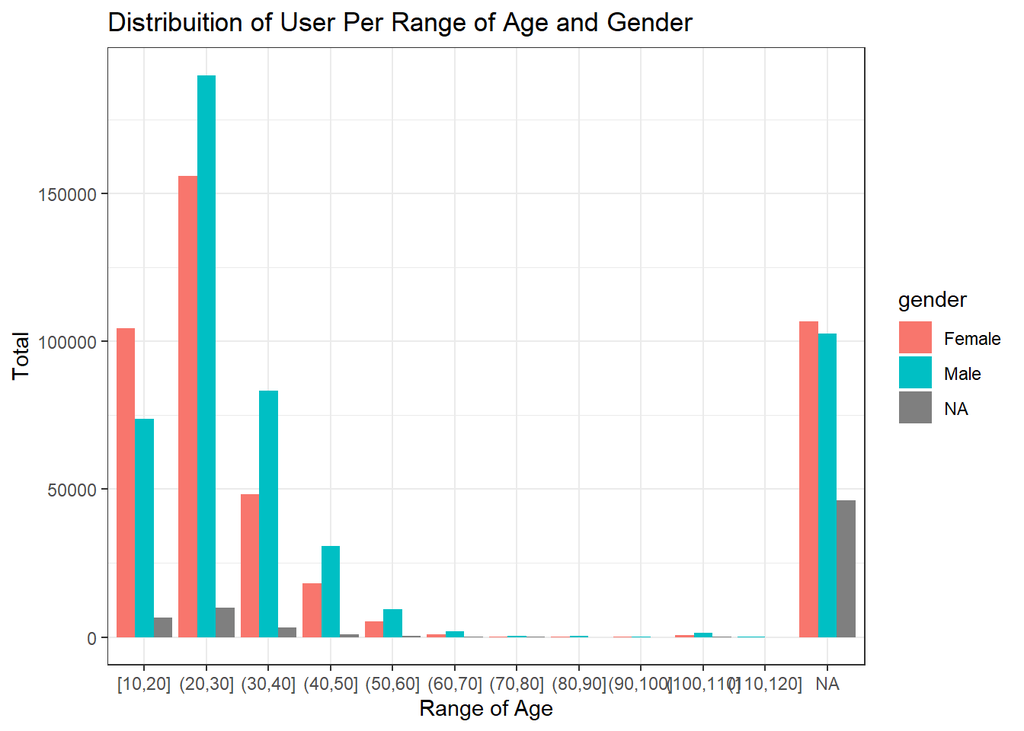

```r
df_user <- df_user %>% mutate(range_age = cut_width(age,10,boundary = 0))

ggplot(df_user) +
  theme_bw() +
  geom_histogram(aes(x = range_age, fill = gender),
                 bins = 30, stat = "count",
                 position="dodge", na.rm = TRUE) +
  labs(x = "Range of Age", y = "Total", title = "Distribuition of User Per Range of Age and Gender")
```

### Treatment Of Outliers

```r
quantile(df_user$age, probs = c(0.01, 0.99), na.rm = T)
```

```
##  1% 99%
##  14  59
```